# Wine Quality Introduction: Understanding the Business Problem

Understanding the factors that influence wine quality is essential for winemakers and industry experts striving to optimize production and marketing strategies. Wine quality depends on a combination of chemical properties, such as acidity, sugar content, and alcohol concentration, which directly impact its taste, aroma, and overall consumer appeal. Identifying patterns in these chemical attributes can help predict wine quality and improve product consistency, helping wineries to make informed decisions about the production processes.

**Objective:** The goal of this report is to predict the quality of wine based on its chemical attributes, enabling wineries to assess product quality efficiently. Wine quality is rated on a scale of 0 to 10 and depends on many factors. We will perform regression analysis on the winequality.csv data set by using Single Linear Regression, Multiple Linear Regression, Regression Trees, Support Vector Regression, and Multi-Layer Perceptron models.

# **Data Understanding and Preprocessing**

The data in the winequality.csv file contains information about chemical attributes and qualities for different wines.

In this step, we will read the excel file to better understand the features and their patterns. We will perform descriptive analysis (i.e., statistics, visualizations) to understand the dataset, the variables and the relationships among them, handle missing values, highly correlated predictors (at 90%+ level), and outliers. We will also split the dataset into training and testing sets to prepare for model development.

**Variables:**

**Fixed Acidity:** non-volatile acids (e.g., tartaric acid) that remain in the wine after fermentation, which plays a role in the wine's tartness and stability.

**Volatile Acidity:** concentration of volatile acids (e.g., acetic acid), which can evaporate. High levels may cause a vinegar-like taste

**Citric Acid:** a weak acid naturally found in wine that adds a refreshing taste and contributes to the wine's acidity.

**Residual Sugar:** The amount of sugar left unfermented in the wine. Determines sweetness levels; higher residual sugar often indicates sweeter wines.  
**Chlorides:** Concentration of salt in the wine. Excessive chlorides can give wine a salty taste

**Free Sulfur Dioxide:** The portion of sulfur dioxide that is unbound and active in the wine, which protects against oxidation and microbial growth.

**Total Sulfur Dioxide:** Sum of free and bound sulfur dioxide in the wine. High levels can affect the aroma and taste, and regulations exist on permissible levels.

**Density:** Measures the wine’s mass per unit volume, often influenced by alcohol and sugar content and helps assess fermentation completeness.

**pH:** Indicates wine acidity, on a scale of 0-14, with lower values being more acidic and can affect microbial stability and taste.

**Sulphates:** Salts of sulfuric acid that enhance wine flavor and act as preservatives.Associated with increased bitterness or dryness in wine.

**Alcohol:** Percentage of ethanol in the wine. Affects body, taste, and perception of quality.

**Target variable:** Quality: Wine quality score, typically rated by wine tasters on a scale (e.g., 0-10).

1. Upload and clean data

```python
# Mounting Google Drive
from google.colab import drive
drive.mount('/content/drive')
```

```python
# Import libraries
import pandas as pd
import seaborn as sns
import matplotlib.pyplot as plt
from sklearn.model_selection import train_test_split
from sklearn import linear_model
from sklearn.tree import DecisionTreeRegressor
from sklearn.svm import SVR
from sklearn.neural_network import MLPRegressor
import statsmodels.api as sm
from sklearn.metrics import mean_squared_error
from sklearn.metrics import mean_absolute_error
from sklearn import preprocessing
```

```python
# Read data
wineData = pd.read_csv('/content/drive/MyDrive/IS470_data/winequality-red.csv')
wineData
```

|  | fixed acidity | volatile acidity | citric acid | residual sugar | chlorides | free sulfur dioxide | total sulfur dioxide | density | pH | sulphates | alcohol | quality |
| --- | --- | --- | --- | --- | --- | --- | --- | --- | --- | --- | --- | --- |
| 0 | 7.4 | 0.700 | 0.00 | 1.9 | 0.076 | 11.0 | 34.0 | 0.99780 | 3.51 | 0.56 | 9.4 | 5 |
| 1 | 7.8 | 0.880 | 0.00 | 2.6 | 0.098 | 25.0 | 67.0 | 0.99680 | 3.20 | 0.68 | 9.8 | 5 |
| 2 | 7.8 | 0.760 | 0.04 | 2.3 | 0.092 | 15.0 | 54.0 | 0.99700 | 3.26 | 0.65 | 9.8 | 5 |
| 3 | 11.2 | 0.280 | 0.56 | 1.9 | 0.075 | 17.0 | 60.0 | 0.99800 | 3.16 | 0.58 | 9.8 | 6 |
| 4 | 7.4 | 0.700 | 0.00 | 1.9 | 0.076 | 11.0 | 34.0 | 0.99780 | 3.51 | 0.56 | 9.4 | 5 |
| ... | ... | ... | ... | ... | ... | ... | ... | ... | ... | ... | ... | ... |
| 1594 | 6.2 | 0.600 | 0.08 | 2.0 | 0.090 | 32.0 | 44.0 | 0.99490 | 3.45 | 0.58 | 10.5 | 5 |
| 1595 | 5.9 | 0.550 | 0.10 | 2.2 | 0.062 | 39.0 | 51.0 | 0.99512 | 3.52 | 0.76 | 11.2 | 6 |
| 1596 | 6.3 | 0.510 | 0.13 | 2.3 | 0.076 | 29.0 | 40.0 | 0.99574 | 3.42 | 0.75 | 11.0 | 6 |
| 1597 | 5.9 | 0.645 | 0.12 | 2.0 | 0.075 | 32.0 | 44.0 | 0.99547 | 3.57 | 0.71 | 10.2 | 5 |
| 1598 | 6.0 | 0.310 | 0.47 | 3.6 | 0.067 | 18.0 | 42.0 | 0.99549 | 3.39 | 0.66 | 11.0 | 6 |

1599 rows × 12 columns

```python
# Examine the number of rows and cols
wineData.shape
```

```
(1599, 12)
```

```python
# Show the head rows of a data frame
wineData.head()
```

|  | fixed acidity | volatile acidity | citric acid | residual sugar | chlorides | free sulfur dioxide | total sulfur dioxide | density | pH | sulphates | alcohol | quality |
| --- | --- | --- | --- | --- | --- | --- | --- | --- | --- | --- | --- | --- |
| 0 | 7.4 | 0.70 | 0.00 | 1.9 | 0.076 | 11.0 | 34.0 | 0.9978 | 3.51 | 0.56 | 9.4 | 5 |
| 1 | 7.8 | 0.88 | 0.00 | 2.6 | 0.098 | 25.0 | 67.0 | 0.9968 | 3.20 | 0.68 | 9.8 | 5 |
| 2 | 7.8 | 0.76 | 0.04 | 2.3 | 0.092 | 15.0 | 54.0 | 0.9970 | 3.26 | 0.65 | 9.8 | 5 |
| 3 | 11.2 | 0.28 | 0.56 | 1.9 | 0.075 | 17.0 | 60.0 | 0.9980 | 3.16 | 0.58 | 9.8 | 6 |
| 4 | 7.4 | 0.70 | 0.00 | 1.9 | 0.076 | 11.0 | 34.0 | 0.9978 | 3.51 | 0.56 | 9.4 | 5 |

```python
# Show the tail rows of a data frame
wineData.tail()
```

|  | fixed acidity | volatile acidity | citric acid | residual sugar | chlorides | free sulfur dioxide | total sulfur dioxide | density | pH | sulphates | alcohol | quality |
| --- | --- | --- | --- | --- | --- | --- | --- | --- | --- | --- | --- | --- |
| 1594 | 6.2 | 0.600 | 0.08 | 2.0 | 0.090 | 32.0 | 44.0 | 0.99490 | 3.45 | 0.58 | 10.5 | 5 |
| 1595 | 5.9 | 0.550 | 0.10 | 2.2 | 0.062 | 39.0 | 51.0 | 0.99512 | 3.52 | 0.76 | 11.2 | 6 |
| 1596 | 6.3 | 0.510 | 0.13 | 2.3 | 0.076 | 29.0 | 40.0 | 0.99574 | 3.42 | 0.75 | 11.0 | 6 |
| 1597 | 5.9 | 0.645 | 0.12 | 2.0 | 0.075 | 32.0 | 44.0 | 0.99547 | 3.57 | 0.71 | 10.2 | 5 |
| 1598 | 6.0 | 0.310 | 0.47 | 3.6 | 0.067 | 18.0 | 42.0 | 0.99549 | 3.39 | 0.66 | 11.0 | 6 |

```python
# Examine missing values
wineData.isnull().sum()
```

|  | 0 |
| --- | --- |
| fixed acidity | 0 |
| volatile acidity | 0 |
| citric acid | 0 |
| residual sugar | 0 |
| chlorides | 0 |
| free sulfur dioxide | 0 |
| total sulfur dioxide | 0 |
| density | 0 |
| pH | 0 |
| sulphates | 0 |
| alcohol | 0 |
| quality | 0 |

**dtype:** int64

```python
#Examine Variable Types
wineData.dtypes
```

|  | 0 |
| --- | --- |
| fixed acidity | float64 |
| volatile acidity | float64 |
| citric acid | float64 |
| residual sugar | float64 |
| chlorides | float64 |
| free sulfur dioxide | float64 |
| total sulfur dioxide | float64 |
| density | float64 |
| pH | float64 |
| sulphates | float64 |
| alcohol | float64 |
| quality | int64 |

**dtype:** object

```python
wineData.describe()
```

|  | fixed acidity | volatile acidity | citric acid | residual sugar | chlorides | free sulfur dioxide | total sulfur dioxide | density | pH | sulphates | alcohol | quality |
| --- | --- | --- | --- | --- | --- | --- | --- | --- | --- | --- | --- | --- |
| count | 1599.000000 | 1599.000000 | 1599.000000 | 1599.000000 | 1599.000000 | 1599.000000 | 1599.000000 | 1599.000000 | 1599.000000 | 1599.000000 | 1599.000000 | 1599.000000 |
| mean | 8.319637 | 0.527821 | 0.270976 | 2.538806 | 0.087467 | 15.874922 | 46.467792 | 0.996747 | 3.311113 | 0.658149 | 10.422983 | 5.636023 |
| std | 1.741096 | 0.179060 | 0.194801 | 1.409928 | 0.047065 | 10.460157 | 32.895324 | 0.001887 | 0.154386 | 0.169507 | 1.065668 | 0.807569 |
| min | 4.600000 | 0.120000 | 0.000000 | 0.900000 | 0.012000 | 1.000000 | 6.000000 | 0.990070 | 2.740000 | 0.330000 | 8.400000 | 3.000000 |
| 25% | 7.100000 | 0.390000 | 0.090000 | 1.900000 | 0.070000 | 7.000000 | 22.000000 | 0.995600 | 3.210000 | 0.550000 | 9.500000 | 5.000000 |
| 50% | 7.900000 | 0.520000 | 0.260000 | 2.200000 | 0.079000 | 14.000000 | 38.000000 | 0.996750 | 3.310000 | 0.620000 | 10.200000 | 6.000000 |
| 75% | 9.200000 | 0.640000 | 0.420000 | 2.600000 | 0.090000 | 21.000000 | 62.000000 | 0.997835 | 3.400000 | 0.730000 | 11.100000 | 6.000000 |
| max | 15.900000 | 1.580000 | 1.000000 | 15.500000 | 0.611000 | 72.000000 | 289.000000 | 1.003690 | 4.010000 | 2.000000 | 14.900000 | 8.000000 |

```python
# Calculate the correlation matrix
wineData.corr()
```

|  | fixed acidity | volatile acidity | citric acid | residual sugar | chlorides | free sulfur dioxide | total sulfur dioxide | density | pH | sulphates | alcohol | quality |
| --- | --- | --- | --- | --- | --- | --- | --- | --- | --- | --- | --- | --- |
| fixed acidity | 1.000000 | -0.256131 | 0.671703 | 0.114777 | 0.093705 | -0.153794 | -0.113181 | 0.668047 | -0.682978 | 0.183006 | -0.061668 | 0.124052 |
| volatile acidity | -0.256131 | 1.000000 | -0.552496 | 0.001918 | 0.061298 | -0.010504 | 0.076470 | 0.022026 | 0.234937 | -0.260987 | -0.202288 | -0.390558 |
| citric acid | 0.671703 | -0.552496 | 1.000000 | 0.143577 | 0.203823 | -0.060978 | 0.035533 | 0.364947 | -0.541904 | 0.312770 | 0.109903 | 0.226373 |
| residual sugar | 0.114777 | 0.001918 | 0.143577 | 1.000000 | 0.055610 | 0.187049 | 0.203028 | 0.355283 | -0.085652 | 0.005527 | 0.042075 | 0.013732 |
| chlorides | 0.093705 | 0.061298 | 0.203823 | 0.055610 | 1.000000 | 0.005562 | 0.047400 | 0.200632 | -0.265026 | 0.371260 | -0.221141 | -0.128907 |
| free sulfur dioxide | -0.153794 | -0.010504 | -0.060978 | 0.187049 | 0.005562 | 1.000000 | 0.667666 | -0.021946 | 0.070377 | 0.051658 | -0.069408 | -0.050656 |
| total sulfur dioxide | -0.113181 | 0.076470 | 0.035533 | 0.203028 | 0.047400 | 0.667666 | 1.000000 | 0.071269 | -0.066495 | 0.042947 | -0.205654 | -0.185100 |
| density | 0.668047 | 0.022026 | 0.364947 | 0.355283 | 0.200632 | -0.021946 | 0.071269 | 1.000000 | -0.341699 | 0.148506 | -0.496180 | -0.174919 |
| pH | -0.682978 | 0.234937 | -0.541904 | -0.085652 | -0.265026 | 0.070377 | -0.066495 | -0.341699 | 1.000000 | -0.196648 | 0.205633 | -0.057731 |
| sulphates | 0.183006 | -0.260987 | 0.312770 | 0.005527 | 0.371260 | 0.051658 | 0.042947 | 0.148506 | -0.196648 | 1.000000 | 0.093595 | 0.251397 |
| alcohol | -0.061668 | -0.202288 | 0.109903 | 0.042075 | -0.221141 | -0.069408 | -0.205654 | -0.496180 | 0.205633 | 0.093595 | 1.000000 | 0.476166 |
| quality | 0.124052 | -0.390558 | 0.226373 | 0.013732 | -0.128907 | -0.050656 | -0.185100 | -0.174919 | -0.057731 | 0.251397 | 0.476166 | 1.000000 |

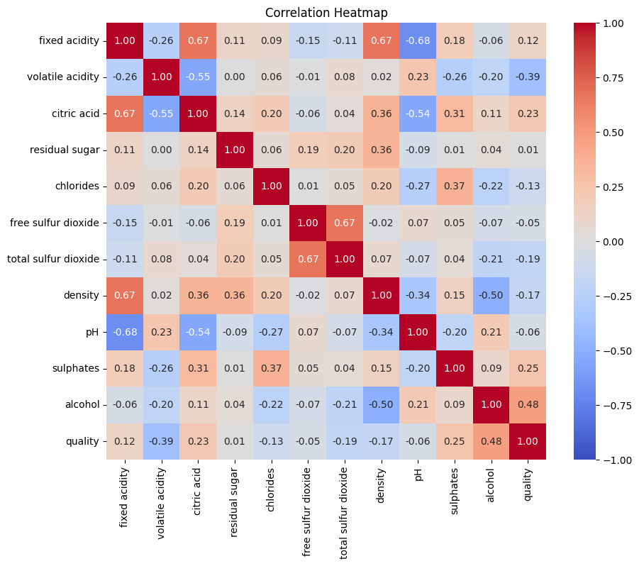

```python
import seaborn as sns
import matplotlib.pyplot as plt
import numpy as np

corr_matrix = wineData.corr()

plt.figure(figsize=(10, 8))
sns.heatmap(corr_matrix, annot=True, cmap="coolwarm", fmt=".2f", vmin=-1, vmax=1)
plt.title("Correlation Heatmap")
plt.show()
```

This correlation heatmap is a visual representation of the correlation between all the features in this dataset. The heatmap shows us that there are non highly correlated predictors (at 90%+ level), and the predictor that has the highest correlation with the target variable "quality" is alcohol with a 48% correlation.

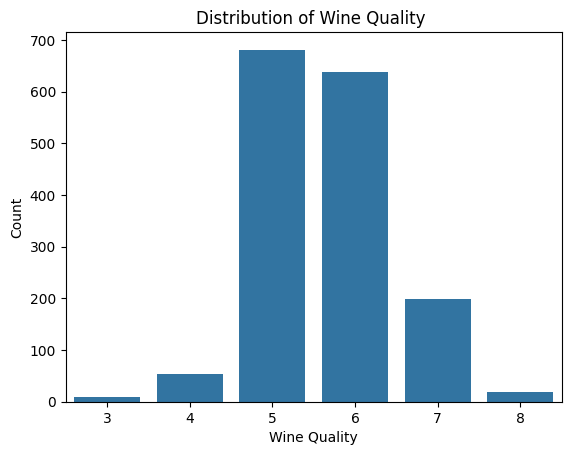

```python
#Countplot of categorical target variable: quality'
sns.countplot(x='quality', data=wineData)
plt.title('Distribution of Wine Quality ')
plt.xlabel('Wine Quality')
plt.ylabel('Count')
plt.show()
```

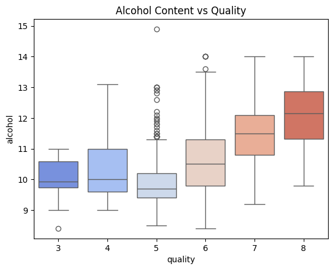

```python
#boxplot for quality and alcohol
sns.boxplot(x="quality", y="alcohol", data=wineData, palette="coolwarm")
plt.title("Alcohol Content vs Quality")
plt.show()
```

These boxplots show that high-rated wines (score = 8) tend to have higher alcohol percentage, while low-rated wines have a lower alcohol percentage. There are quite a few outliers for wines rated 5 that have higher alcohol content, which can be a resultof central tendency bias, where people tend to rate things averagely. The outliers can also mean other predictors may have played a role in how the wine was rated.

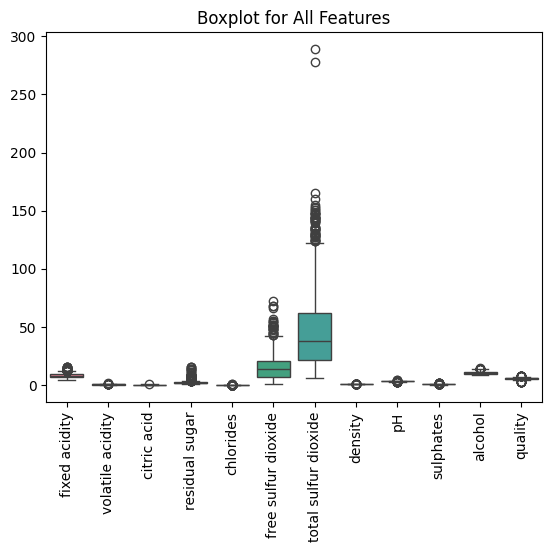

```python
# Boxplot for each feature
sns.boxplot(data=wineData[['fixed acidity', 'volatile acidity', 'citric acid', 'residual sugar',
                           'chlorides', 'free sulfur dioxide', 'total sulfur dioxide', 'density',
                           'pH', 'sulphates', 'alcohol', 'quality']])
plt.xticks(rotation=90)
plt.title('Boxplot for All Features')
plt.show()
```

These boxplots show that there are slight outliers for all of the features. The total sulfer dioxide variable has a different scale than the rest of the features which makes it seem like it has a larger amount of outliers.

```python
# Split the data into train and test
target = wineData['quality']
predictors = wineData.drop(['quality'],axis=1)
predictors_train, predictors_test, target_train, target_test = train_test_split(predictors, target, test_size=0.3, random_state=0)
print(predictors_train.shape, predictors_test.shape, target_train.shape, target_test.shape)
```

```
(1119, 11) (480, 11) (1119,) (480,)
```

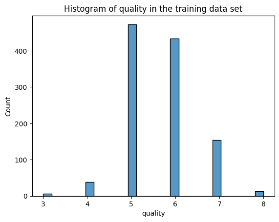

```python
# Examine the distribution of target variable for training data set
snsplot = sns.histplot(data = target_train)
snsplot.set_title("Histogram of quality in the training data set")
```

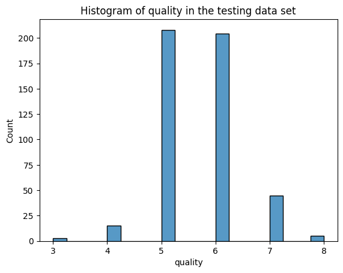

```python
# Examine the distribution of target variable for testing data set
snsplot = sns.histplot(data = target_test)
snsplot.set_title("Histogram of quality in the testing data set")
```

```python
correlations = wineData.corr()
quality_corr = correlations['quality'].sort_values(ascending=False)
print(quality_corr)
```

```
quality                 1.000000
alcohol                 0.476166
sulphates               0.251397
citric acid             0.226373
fixed acidity           0.124052
residual sugar          0.013732
free sulfur dioxide    -0.050656
pH                     -0.057731
chlorides              -0.128907
density                -0.174919
total sulfur dioxide   -0.185100
volatile acidity       -0.390558
Name: quality, dtype: float64
```

For the analysis, no features were removed from the dataset due to high correlation, and the analysis focused on predictors that provided the most valuable information for predicting wine quality.

# Single Linear Regression

The simple linear regression model aims to predict the quality of wine based on one chemical attribute. We chose alcohol as the primary predictor in this model because we found it to have the highest correlation to the quality score of the wines. The goal is to determine how well this single predictor explains the variation in wine quality. By fitting a linear equation to the data, simple linear regression provides insights into the strength and direction of the relationship between the two variables.

```python
# Build a simple linear regression model with only bmi as predictor (only one single variable to predict y)
model_alcohol= linear_model.LinearRegression()
model_alcohol.fit(predictors_train[['alcohol']], target_train)
```

```
LinearRegression()
```

```python
# Show model summary
import statsmodels.api as sm
X2 = sm.add_constant(predictors_train[['alcohol']])
y = target_train
est = sm.OLS(y, X2)
est2 = est.fit()
print(est2.summary())
```

```
                            OLS Regression Results
==============================================================================
Dep. Variable:                quality   R-squared:                       0.214
Model:                            OLS   Adj. R-squared:                  0.213
Method:                 Least Squares   F-statistic:                     303.8
Date:                Mon, 25 Nov 2024   Prob (F-statistic):           2.29e-60
Time:                        06:20:41   Log-Likelihood:                -1235.3
No. Observations:                1119   AIC:                             2475.
Df Residuals:                    1117   BIC:                             2485.
Df Model:                           1
Covariance Type:            nonrobust
==============================================================================
                 coef    std err          t      P>|t|      [0.025      0.975]
------------------------------------------------------------------------------
const          1.9289      0.215      8.985      0.000       1.508       2.350
alcohol        0.3576      0.021     17.430      0.000       0.317       0.398
==============================================================================
Omnibus:                       24.052   Durbin-Watson:                   2.102
Prob(Omnibus):                  0.000   Jarque-Bera (JB):               39.006
Skew:                          -0.173   Prob(JB):                     3.39e-09
Kurtosis:                       3.847   Cond. No.                         104.
==============================================================================

Notes:
[1] Standard Errors assume that the covariance matrix of the errors is correctly specified.
```

```python
# Make predictions on testing data
prediction_on_test = model_alcohol.predict(predictors_test[['alcohol']])
```

```python
# Examine the evaluation results on testing data: MAE and RMSE
MAE = mean_absolute_error(target_test, prediction_on_test)
RMSE = mean_squared_error(target_test, prediction_on_test, squared=False)
print("MAE:", MAE)
print("RMSE:", RMSE)
```

```
MAE: 0.5230974814995663
RMSE: 0.6623121357628291
```

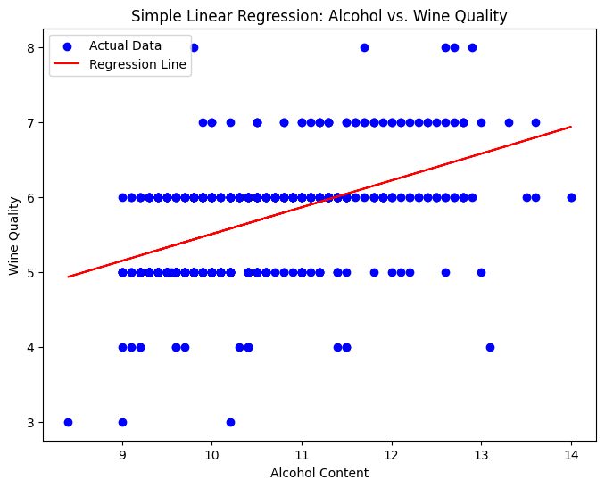

```python
predictions = model_alcohol.predict(predictors_test[['alcohol']])
plt.figure(figsize=(8, 6))
plt.scatter(predictors_test['alcohol'], target_test, color='blue', label='Actual Data')
plt.plot(predictors_test['alcohol'], predictions, color='red', label='Regression Line')

# Add labels and title
plt.xlabel('Alcohol Content')
plt.ylabel('Wine Quality')
plt.title('Simple Linear Regression: Alcohol vs. Wine Quality')

# Show the legend
plt.legend()
plt.show()
```

The OLS regression analysis shows that alcohol content is a statistically significant predictor of wine quality, with a coefficient of 0.3576, indicating that an increase in alcohol content is associated with an increase in wine quality. However, the model's R-squared value of 0.214 suggests that only 21.4% of the variation in wine quality can be explained by alcohol alone, indicating that other factors likely influence wine quality. To improve prediction accuracy, incorporating additional variables or using more advanced models could help capture more of the underlying factors affecting wine quality.

# Multiple Linear Regression

In the Multi-Linear Regression model, we aim to predict wine quality based on several chemical attributes, such as fixed acidity, volatile acidity, citric acid, residual sugar, chlorides, sulfur dioxide levels, density, pH, sulphates, and alcohol content. Unlike simple linear regression, which uses only one predictor variable, multiple linear regression allows us to consider the combined influence of multiple factors on the dependent variable. By fitting a linear model to these features, we can assess how each chemical attribute contributes to the predicted wine quality and gain a more comprehensive understanding of the factors that drive wine quality ratings.

```python
# Build a multiple linear regression model with all predictors
model_MLR = linear_model.LinearRegression()
model_MLR.fit(predictors_train, target_train)
```

```
LinearRegression()
```

```python
# Show model summary
import statsmodels.api as sm
X2 = sm.add_constant(predictors_train)
y = target_train
est = sm.OLS(y, X2)
est2 = est.fit()
print(est2.summary())
```

```
                            OLS Regression Results
==============================================================================
Dep. Variable:                quality   R-squared:                       0.371
Model:                            OLS   Adj. R-squared:                  0.365
Method:                 Least Squares   F-statistic:                     59.35
Date:                Mon, 25 Nov 2024   Prob (F-statistic):          1.86e-103
Time:                        07:51:52   Log-Likelihood:                -1110.6
No. Observations:                1119   AIC:                             2245.
Df Residuals:                    1107   BIC:                             2305.
Df Model:                          11
Covariance Type:            nonrobust
========================================================================================
                           coef    std err          t      P>|t|      [0.025      0.975]
----------------------------------------------------------------------------------------
const                   21.0111     25.418      0.827      0.409     -28.861      70.883
fixed acidity            0.0202      0.031      0.651      0.515      -0.041       0.081
volatile acidity        -1.2139      0.142     -8.537      0.000      -1.493      -0.935
citric acid             -0.0985      0.180     -0.548      0.584      -0.451       0.254
residual sugar           0.0221      0.018      1.259      0.208      -0.012       0.057
chlorides               -1.8976      0.484     -3.925      0.000      -2.846      -0.949
free sulfur dioxide      0.0020      0.003      0.774      0.439      -0.003       0.007
total sulfur dioxide    -0.0030      0.001     -3.534      0.000      -0.005      -0.001
density                -16.7249     25.954     -0.644      0.519     -67.649      34.199
pH                      -0.3977      0.230     -1.733      0.083      -0.848       0.053
sulphates                0.8542      0.132      6.459      0.000       0.595       1.114
alcohol                  0.2675      0.031      8.533      0.000       0.206       0.329
==============================================================================
Omnibus:                       17.572   Durbin-Watson:                   2.098
Prob(Omnibus):                  0.000   Jarque-Bera (JB):               22.901
Skew:                          -0.192   Prob(JB):                     1.06e-05
Kurtosis:                       3.586   Cond. No.                     1.15e+05
==============================================================================

Notes:
[1] Standard Errors assume that the covariance matrix of the errors is correctly specified.
[2] The condition number is large, 1.15e+05. This might indicate that there are
strong multicollinearity or other numerical problems.
```

```python
# Make predictions on testing data
prediction_on_test = model_MLR.predict(predictors_test)
```

```python
# Examine the evaluation results on testing data: MAE and RMSE
MAE = mean_absolute_error(target_test, prediction_on_test)
RMSE = mean_squared_error(target_test, prediction_on_test, squared=False)
print("MAE:", MAE)
print("RMSE:", RMSE)
```

```
MAE: 0.48712621645927945
RMSE: 0.6330721652189464
```

For this model, the R-squared value of 0.371 means that approximately 37.1% of the variability in wine quality can be explained by the predictors in the model. This suggests that there may be other factors influencing wine quality that are not captured by the current set of variables.

**Interpretation of Coefficients:**

**Fixed Acidity (0.0202):** For every one-unit increase in fixed acidity, the wine quality is expected to increase by 0.0202, holding other factors constant. However, this is not statistically significant (p-value = 0.515), so we can’t conclude that fixed acidity has a meaningful effect on wine quality.

**Volatile Acidity (-1.2139):** A one-unit increase in volatile acidity is associated with a decrease in wine quality by 1.2139 units, holding all other factors constant. This coefficient is statistically significant (p-value = 0.000), meaning volatile acidity negatively impacts wine quality.

**Citric Acid (-0.0985):** For each one-unit increase in citric acid, wine quality decreases by 0.0985. However, this is not statistically significant (p-value = 0.584), suggesting that citric acid may not play a major role in determining wine quality.

**Residual Sugar (0.0221):** Each one-unit increase in residual sugar corresponds to a 0.0221 increase in wine quality, though this is not statistically significant (p-value = 0.208).

**Chlorides (-1.8976):** For each one-unit increase in chlorides, wine quality decreases by 1.8976. This coefficient is statistically significant (p-value = 0.000), meaning chlorides have a strong negative relationship with wine quality.

**Free Sulfur Dioxide (0.0020):** A one-unit increase in free sulfur dioxide corresponds to a 0.0020 increase in wine quality, though this is not statistically significant (p-value = 0.439).

**Total Sulfur Dioxide (-0.0030):** A one-unit increase in total sulfur dioxide leads to a decrease in wine quality by 0.0030, and this is statistically significant (p-value = 0.000).

**Density (-16.7249):** Density is negatively correlated with wine quality. A one-unit increase in density decreases wine quality by 16.7249. This coefficient is not statistically significant (p-value = 0.519).

**pH (-0.3977): **A one-unit increase in pH corresponds to a 0.3977 decrease in wine quality, but this is only marginally significant (p-value = 0.083), suggesting a weak relationship.

**Sulphates (0.8542): **A one-unit increase in sulphates increases wine quality by 0.8542, and this coefficient is statistically significant (p-value = 0.000), meaning sulphates have a positive impact on wine quality.

**Alcohol (0.2675):** For every one-unit increase in alcohol, wine quality increases by 0.2675. This is statistically significant (p-value = 0.000), indicating that alcohol content has a positive effect on wine quality.

**Significance of the Top 3 Most Important Variables:**

**Chlorides:** Chlorides have a negative coefficient of -1.8976, meaning that higher chloride concentrations result in a decrease in wine quality. This variable is statistically significant (p-value = 0.000), making it another critical factor affecting wine quality.

**Alcohol:** Alcohol has a positive coefficient of 0.2675, which means that higher alcohol content is associated with better wine quality. This variable is statistically significant (p-value = 0.000), suggesting a strong positive impact on wine quality.

From the regression results, volatile acidity, chlorides, and alcohol are the most impactful predictors of wine quality. Volatile acidity and chlorides have negative relationships with wine quality, while alcohol has a positive impact. These predictors can be valuable when trying to understand the factors that drive the quality of wine in this dataset

# Regression Trees

Next, we will apply regression trees to predict wine quality based on the chemical features, evaluate the model’s performance, and compare its accuracy with other regression methods like linear regression.

```python
# Build a regression tree model with max_depth=3
model_RT= DecisionTreeRegressor(random_state=0, max_depth=3)
model_RT.fit(predictors_train, target_train)
```

```
DecisionTreeRegressor(max_depth=3, random_state=0)
```

[output not shown]

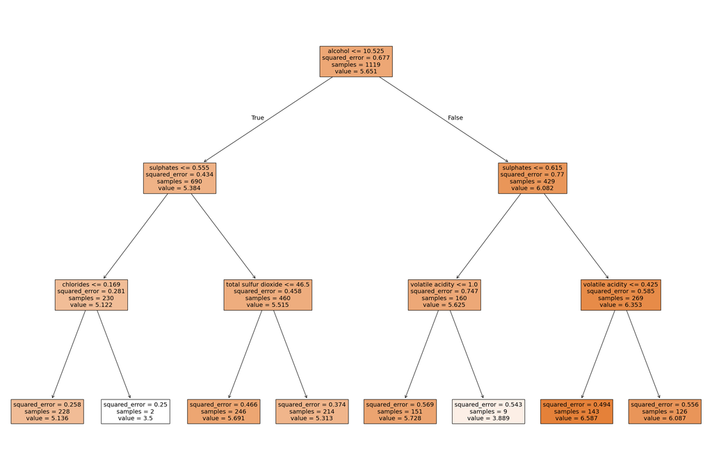

```python
from matplotlib import pyplot as plt
from sklearn import tree
fig = plt.figure(figsize=(30,20))
tree.plot_tree(model_RT,
               feature_names=list(predictors_train.columns),
               filled=True)
```

```python
# Make predictions on testing data
prediction_on_test = model_RT.predict(predictors_test)
```

```python
# Examine the evaluation results on testing data: MAE and RMSE
MAE = mean_absolute_error(target_test, prediction_on_test)
RMSE = mean_squared_error(target_test, prediction_on_test, squared=False)
print("MAE:", MAE)
print("RMSE:", RMSE)
```

```
MAE: 0.5453637284748408
RMSE: 0.6980934560458724
```

```python
# Build a regression tree model with max_depth=3
model_RT2= DecisionTreeRegressor(random_state=0, max_depth=5)
model_RT2.fit(predictors_train, target_train)
```

```
DecisionTreeRegressor(max_depth=5, random_state=0)
```

[output not shown]

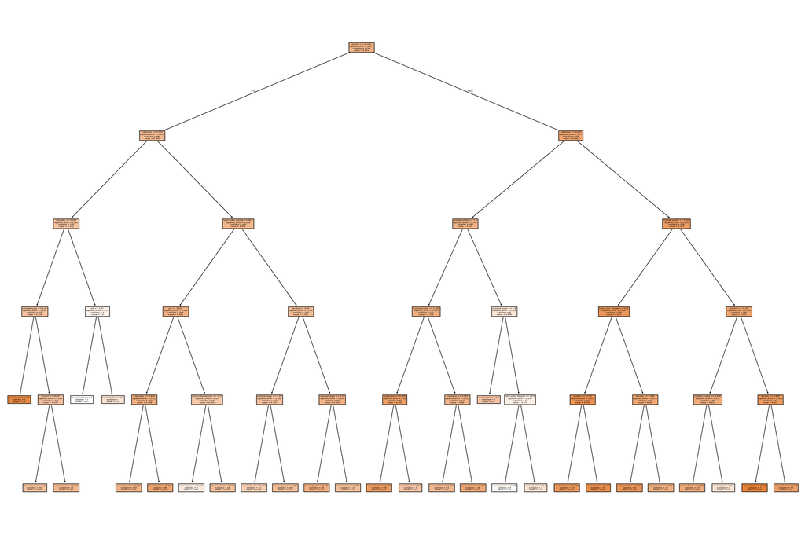

```python
from matplotlib import pyplot as plt
from sklearn import tree
fig = plt.figure(figsize=(30,20))
tree.plot_tree(model_RT2,
               feature_names=list(predictors_train.columns),
               filled=True)
```

```python
# Make predictions on testing data
prediction_on_test = model_RT2.predict(predictors_test)
```

```python
# Examine the evaluation results on testing data: MAE and RMSE
MAE = mean_absolute_error(target_test, prediction_on_test)
RMSE = mean_squared_error(target_test, prediction_on_test, squared=False)
print("MAE:", MAE)
print("RMSE:", RMSE)
```

```
MAE: 0.5256979243158028
RMSE: 0.6941992663274339
```

We experimented with a couple of regression trees (and tested higher max_depth levels as well which are not shown) to create a more accurate tree. The root node for both trees was alcohol. The model with a depth of 5 shows slightly better performance than the depth of 3 in terms of MAE and RMSE, with both error metrics improving marginally. This suggests that the deeper tree is able to capture more complexity in the data, leading to slightly more accurate predictions. However, the improvements are relatively small, indicating that the increase in depth may not be dramatically enhancing the model’s ability to predict wine quality.

# Support Vector Regression (SVR)

```python
# Build a SVM model with default setting (C = 1.0)
model_SVR1 = SVR()
model_SVR1.fit(predictors_train, target_train)
```

```
SVR()
```

```python
# Make predictions on testing data
prediction_on_test = model_SVR1.predict(predictors_test)
```

```python
# Examine the evaluation results on testing data: MAE and RMSE
MAE = mean_absolute_error(target_test, prediction_on_test)
RMSE = mean_squared_error(target_test, prediction_on_test, squared=False)
print("MAE:", MAE)
print("RMSE:", RMSE)
```

```
MAE: 0.5372875742404191
RMSE: 0.7131247064180449
```

```python
# Build a SVM model with C = 10.0
model_SVR2 = SVR(C = 10.0)
model_SVR2.fit(predictors_train, target_train)
```

```
SVR(C=10.0)
```

```python
# Make predictions on testing data (0.5 points)
prediction_on_test = model_SVR2.predict(predictors_test)
```

```python
# Examine the evaluation results on testing data: MAE and RMSE (0.5 points)
MAE = mean_absolute_error(target_test, prediction_on_test)
RMSE = mean_squared_error(target_test, prediction_on_test, squared=False)
print("MAE:", MAE)
print("RMSE:", RMSE)
```

```
MAE: 0.4940382849958881
RMSE: 0.6467564770982447
```

```python
# Build a SVM model with C = 100.0 (0.5 points)
model_SVR3 = SVR(C = 100.0)
model_SVR3.fit(predictors_train, target_train)
```

```
SVR(C=100.0)
```

```python
# Make predictions on testing data (0.5 points)
prediction_on_test = model_SVR3.predict(predictors_test)
```

```python
# Examine the evaluation results on testing data: MAE and RMSE (0.5 points)
MAE = mean_absolute_error(target_test, prediction_on_test)
RMSE =  mean_squared_error(target_test, prediction_on_test, squared=False)
print("MAE:", MAE)
print("RMSE:", RMSE)
```

```
MAE: 0.4804593094240977
RMSE: 0.6260026845036791
```

# Multi-layer Perceptron (MLP)

We will build 3 MLP models with different architectures and evaluate the MLP models and interpret their performance.

```python
#Build MLP model contains two hidden layers: 16 hidden nodes for the first layer, and 8 hidden nodes for the second layer. Set random_state=1.
model_MLP1 = MLPRegressor(hidden_layer_sizes=(16,8,8), random_state=1)
model_MLP1.fit(predictors_train, target_train)
```

```
MLPRegressor(hidden_layer_sizes=(16, 8, 8), random_state=1)
```

```python
# Make predictions on testing data
prediction_on_test= model_MLP1.predict(predictors_test)
```

```python
# Examine the evaluation results on testing data: MAE and RMSE
MAE = mean_absolute_error(target_test, prediction_on_test)
RMSE = mean_squared_error(target_test, prediction_on_test, squared=False)
print("MAE:", MAE)
print("RMSE:", RMSE)
```

```
MAE: 0.52274105994483
RMSE: 0.6705002254345432
```

```python
# Build MLP model contains three hidden layers:
model_MLP2 = MLPRegressor(hidden_layer_sizes=(50,50,50), random_state=1)
model_MLP2.fit(predictors_train, target_train)
```

[output not shown]

```python
# Make predictions on testing data (0.5 points)
prediction_on_test = model_MLP2.predict(predictors_test)
```

```python
# Examine the evaluation results on testing data: MAE and RMSE (0.5 points)
MAE = mean_absolute_error(target_test, prediction_on_test)
RMSE = mean_squared_error(target_test, prediction_on_test, squared=False)
print("MAE:", MAE)
print("RMSE:", RMSE)
```

```
MAE: 0.5112028692456433
RMSE: 0.6450232793194539
```

```python
# Build MLP model contains three hidden layers:
model_MLP3 = MLPRegressor(hidden_layer_sizes=(100,100,100), random_state=1)
model_MLP3.fit(predictors_train, target_train)
```

```
MLPRegressor(hidden_layer_sizes=(100, 100, 100), random_state=1)
```

```python
# Make predictions on testing data (0.5 points)
prediction_on_test = model_MLP3.predict(predictors_test)
```

```python
# Examine the evaluation results on testing data: MAE and RMSE (0.5 points)
MAE = mean_absolute_error(target_test, prediction_on_test)
RMSE = mean_squared_error(target_test, prediction_on_test, squared=False)
print("MAE:", MAE)
print("RMSE:", RMSE)
```

```
MAE: 0.5144653254231419
RMSE: 0.6539368247642598
```

# Model Comparison

```python
modelComp = pd.read_excel('/content/drive/MyDrive/IS470_data/winequality_models.xlsx')
modelComp
```

[output not shown]

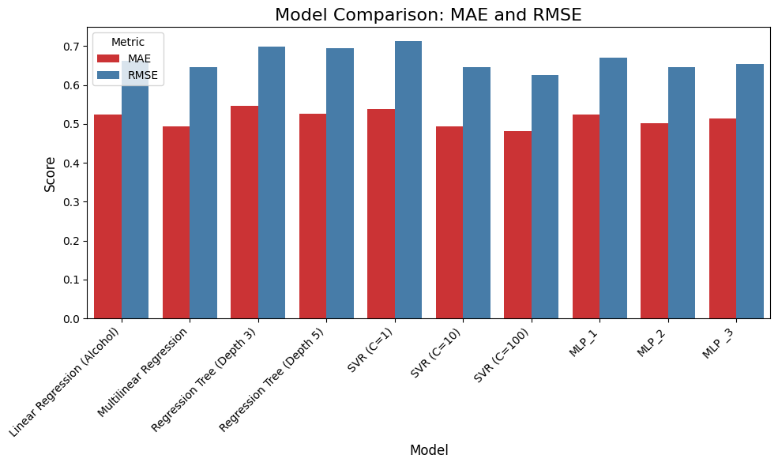

```python
#modelComp= modelComp.melt(id_vars=['Model'], value_vars=['MAE', 'RMSE'],  var_name='Metric', value_name='Score')

plt.figure(figsize=(10, 6))
ax = sns.barplot(data=modelComp, x='Model', y='Score', hue='Metric', palette='Set1')

# Set plot labels and title
plt.title('Model Comparison: MAE and RMSE', fontsize=16)
plt.xlabel('Model', fontsize=12)
plt.ylabel('Score', fontsize=12)
plt.xticks(rotation=45, ha='right')
plt.tight_layout()

# Show the plot
plt.show()
```

Simple Linear Regression is is a straightforward model that assumes a linear relationship between the input features and the target variable (wine quality). It gives us a basic understanding of how well we can predict wine quality using a simple approach.This model provides a starting point for evaluating the performance of more complex models, but has a moderate error in both MAE and RMSE. Its simplicity could be beneficial for interpretability but may underperform compared to more complex models.

Multiple Linear Regression model performs better than the simple linear regression by reducing the MAE and RMSE values. It takes into account multiple predictors, which can capture more variability in the data and show how different predictors affect the quality of the wine.

Regression trees perform worse than linear models in this case, particularly at depth 3, where the model is too simple. A depth of 5 slightly improves performance but still doesn't match the best-performing linear models or SVR. In general, regression trees are better suited for complex, nonlinear relationships, instead of more linear relationships as in this case of wine quality. There is also a high possibility of overfitting the model when creating a more complex regression tree.

The support Vector Regression (SVR) models perform well with increasing values of C. The highest-performing model (C=100) has the lowest MAE and RMSE, showing that this model is good at capturing non-linear patterns in the data. SVR also is good at avoiding overfitting.

The MLP models have similar performance. MLP_2 performs the best with the lowest MAE and RMSE. These models perform better than some of the simpler regression models but may require more tuning to improve further.Generally MLP models require larger datasets, but can describe more complex relationships in data.

Overall, the SVR (C=100) model is the most suitable for predicting wine quality, with the lowest MAE (0.4805) and RMSE (0.6260). It performs well in capturing complex, non-linear relationships within the dataset. However, Multiple Linear Regression and MLP2 (3 layers, 50 nodes each) models also perform very well, and they might be more interpretable.

```python
#!jupyter nbconvert --to html "/content/drive/MyDrive/Colab Notebooks/SiddiquiNeha_Assignment3.ipynb"
```